# Python Basics

### Modules (Numpy and OpenCV)

In the following section we will be covering modules. Above, we leaned about functions and the power that they have. Modules let us use functions that other people have created to solve problems that we commonly incounter. For example, if we find that we frequently have to get a random number, instead of coding it every time, you could just import a function that either you or someone else created in the past. Basically, modules and importing lets us have access to the work of many other coders, making it a very powerful tool.

Below, we will import the numpy module and use a few of its functions to show off this power

Here, we rename it to np to make it more easily accessable

```python
import numpy as np
```

Numpy is a library which is coded outside of python, making it faster. It gives us access to better and more efficient lists

With it, we can make a list like this:

```python
my_array = np.zeros((2,3)) # (2,3) is the shape of the array
my_array
```

```
array([[0., 0., 0.],
       [0., 0., 0.]])
```

or like this:

```python
np.random.rand(3,2) # we don't need to put the shape in braces this time
```

```
array([[0.04912864, 0.60777123],
       [0.5187959 , 0.35016874],
       [0.36002124, 0.94697975]])
```

Just like regular variables, we can do opperations on this list

```python
my_array2 = my_array + 1
my_array3 = my_array2 * 2
my_array2, my_array3
```

```
(array([[1., 1., 1.],
        [1., 1., 1.]]), array([[2., 2., 2.],
        [2., 2., 2.]]))
```

Make an array from my_array of all -3s:

```python
#Pillow will be used for image processing
from PIL import Image
#reading images from url using skimage
from skimage import io
#plt used to display images
import matplotlib.pyplot as plt
```

First, we want to get the url of a particular image

```python
url = "https://www.akc.org/wp-content/uploads/2017/11/GettyImages-187066830.jpg"
```

Next, we want to read in the image from the url as a numpy array in RGB format and display it. The shape of the image is (512, 768, 3), meaning the dimensions of the image are 512x768 and there are 3 color channels (red, green, blue)

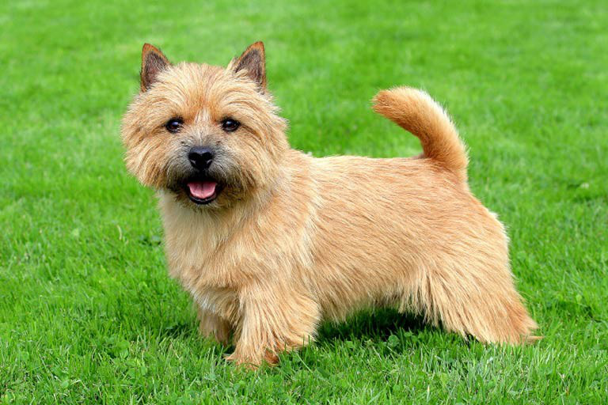

```python
#turn the built in axis display of pyplot off
plt.axis("off")

img = io.imread(url)
plt.imshow(img)
plt.show()
```

Our image is a little too large, let's first convert it to a Pillow image. Pillow is a convenient library that gives us a lot of image processing functions. We can then use the built in resizing function of a PIL image to resize it to 180x180.

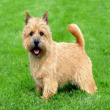

```python
from PIL import Image

plt.axis("off")

pil_img = Image.fromarray(io.imread(url))
pil_img = pil_img.resize((180, 180))
plt.imshow(pil_img)
plt.show()
```

Now, let's try to cast an image to only blue! pil_img.split splits an image to 3 channels of pattern: red, green, blue. We can then zero out the red and green channels (convert them to zero so they aren't displayed). Finally, we can display the blue image by merging the channels back into one image (using the Image.merge function) and displaying the result!

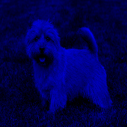

```python
plt.axis("off")

#zero out red and green channels
r,g,b = pil_img.split()
r = r.point(lambda i: i * 0)
g = g.point(lambda i: i * 0)

#display image
result = Image.merge('RGB', (r,g,b))
plt.imshow(result)
plt.show()
```

Finally, let's try and rotate this image!

[figure not shown]

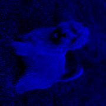

```python
plt.axis("off")

result = result.rotate(270) #rotate 270 degrees counterclockwise
plt.imshow(result)
plt.show()
```

Below, find your own image, display it, resize it to your choosing, make the image only green or red, and then rotate it!

If you are coding this on your own, you may need to install packages like numpy or OpenCV, which we will get into later, but there are many built in packages as well

time allows us to access the current time

```python
import time
time.time() # you will see this go up as you rerun it
```

```
1655747907.4349885
```

random allows us to get random numbers

```python
import random
random.randint(0,5) # this gives one of the numbers between and including 0 and 5
```

```
1
```

Find a built in module and use it here:

You may notice that we have to call the function we need by placing it after the module connected by a dot

But many times, that is inconvenient and we can get around it like this

```python
from random import randint
randint(0,5) # now we can exclude the random. prefix
```

```
4
```

finally, as we did with the numpy module, we can rename the function

```python
from time import time as t
t()
```

```
1655747915.1418505
```